# Examining Climate Change and its Potential Implications in Oklahoma

Claudia Chandra

02/20/2017

## Introduction:

Oklahoma covers 181,035km2 of land and is the 20th largest state in the United States. It is located between the Great Plains and the Ozark Plateau, with high plains located on its Western boundaries and low wetlands on its Southeastern borders. Historically, Oklahoma was highly dependent upon its oil industry; however, because of economic downturns, it diversified its production and is now a leading producer of natural gas and agricultural products, as well as oil. For this reason, its economy relies on energy, telecommunications, and biotechnology. Oklahoma City and Tulsa are the state’s leading economic anchors, with nearly two-thirds of their total population living within the metropolitan regions of these two cities.

[figure not shown]

Source: http://www.state-maps.org/ok-map.htm

In recent years, Oklahoma has experienced a significant increase in extreme weather conditions and earthquakes with magnitude 3.0+. In 2010, the state reported 41 of such cases, and in 2016 the number had increased to 623. The number of reports has decreased from 903 in 2015 following the implementation of stricter fracking regulations (earthquakes.ok.gov).

In terms of climate change, annual mean temperatures in Oklahoma are predicted to rise by approximately 2.5°F by 2040. This number nearly doubles the 1.3°F increase in mean temperature that occurred between 1993 and 2008. Despite such evidence, nearly 25% of Oklahoma’s residents believe that global warming is a myth. The percentage is even higher, reaching 42% in more skeptic counties such as Woodward County (Sutter).

## Objectives:

I wanted to find out whether the citizens of Oklahoma had a reason to doubt climate change. Even though global warming has been proven to occur, science now understands that equalizing the level of climate change across the globe is a hasty generalization. This is because different geographical regions are affected by global warming in unique ways and to different extents.

To prove or disprove climate change in Oklahoma, this research aims to:

- Evaluate temperature records from a weather station located at Tulsa International Airport and determine if a trend exists
- Assess if average weather conditions have been changing, and if so, in what way
- Examine the potential implications of climate change for Oklahoma by looking at current literature and evidence from the past

## Methodology:

If there is a visible trend in the graph, a regression line (or best-fit line) will then be generated and analyzed to find a P-value. P-values are used to test statistical significance in a hypothesis test. It determines how our data supports the null hypothesis being true. The null hypothesis assumes no effect, or in this case no clear evidence that climate change has occurred. To clarify:

- Higher P-values: the data agrees with the null hypothesis
- Lower P-values: the data disagrees with the null hypothesis

The null hypothesis can be rejected if the P-value is lower than 0.05 as this means that a significant difference, or in our case temperature change, does exist. If the P-value is greater than 0.05, the results were statistically insignificant.

As climate change involves rainfall and water availability, changes in precipitation (measured in cm) will also be analyzed using data collected from the same source. Daily precipitation will be averaged to find annual mean precipitation, and the dataset will be plotted on a graph to find a potential trend line. We should also be able to find the rate at which precipitation is changing in the area.

## Results and Interpretation:

# Average Maximum Temperature - June

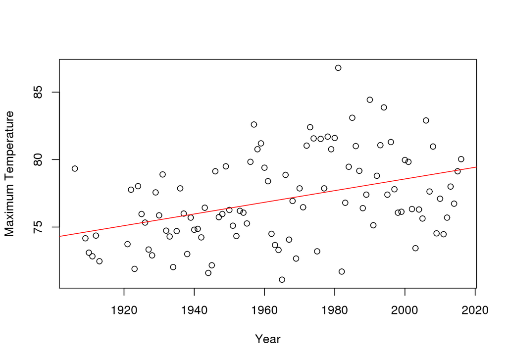

Temperature Change (°F/ year) : 0.0432686

(°F/ 100 years): 4.327

Let’s first have a look at the average maximum temperatures for June. The graph shows an upward trend and an increase in temperature of 4.327°F/ 100 years. The p-value for this graph is 3.338e–05 (or 0.00003338), which is less than 0.05 and therefore significant. Consequently, the null hypothesis can be rejected and a relationship between time and temperature is confirmed.

# Average Maximum Temperature - December

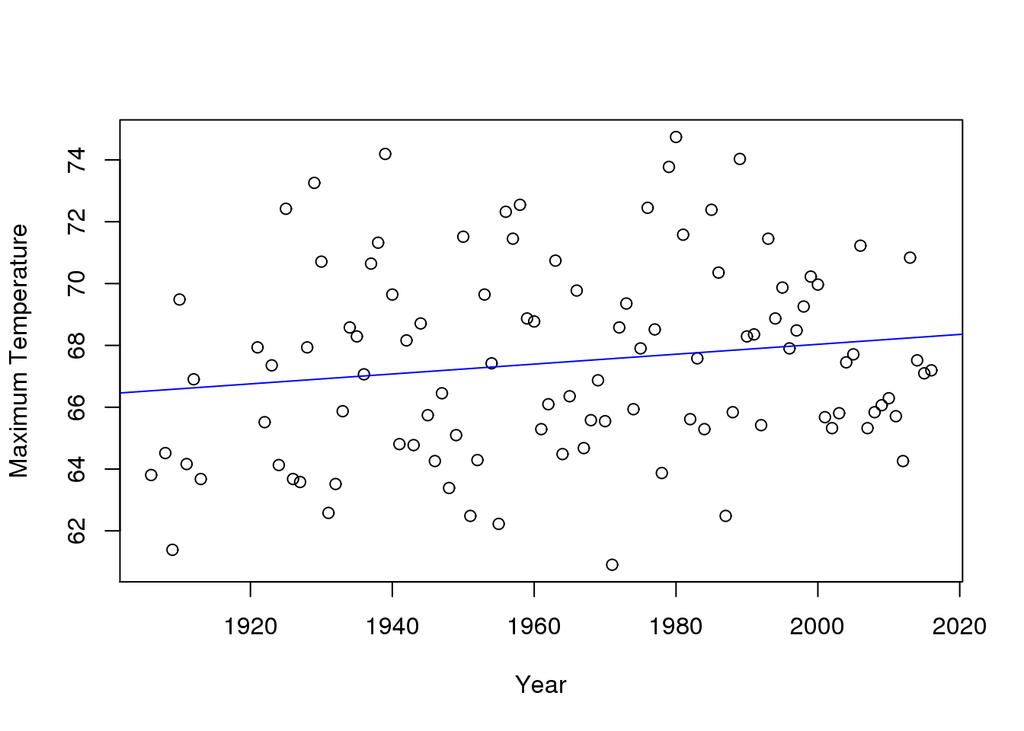

Temperature Change (°F/ year): : 0.0159977

(°F/ 100 years): 1.6

P-value: 0.1122.

In the case of maximum temperatures for December, a slight upward trend of 1.6°F/ 100 years is observed. However, the data’s p-value is 0.1122 and larger than 0.05. As such, the null hypothesis cannot be ignored and a significant relationship between time and temperature cannot be established for this month.

# Average Minimum Temperature - June

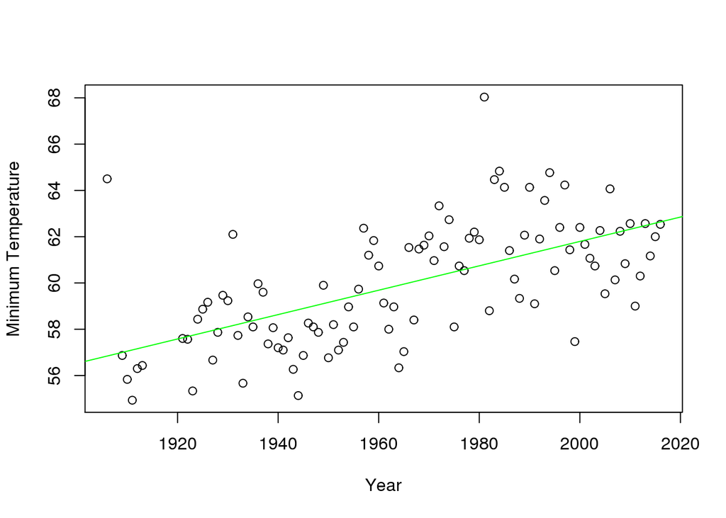

Temperature Change (°F/ year): 0.0526848

(°F/ 100 years): 5.268

# Average Minimum Temperature - December

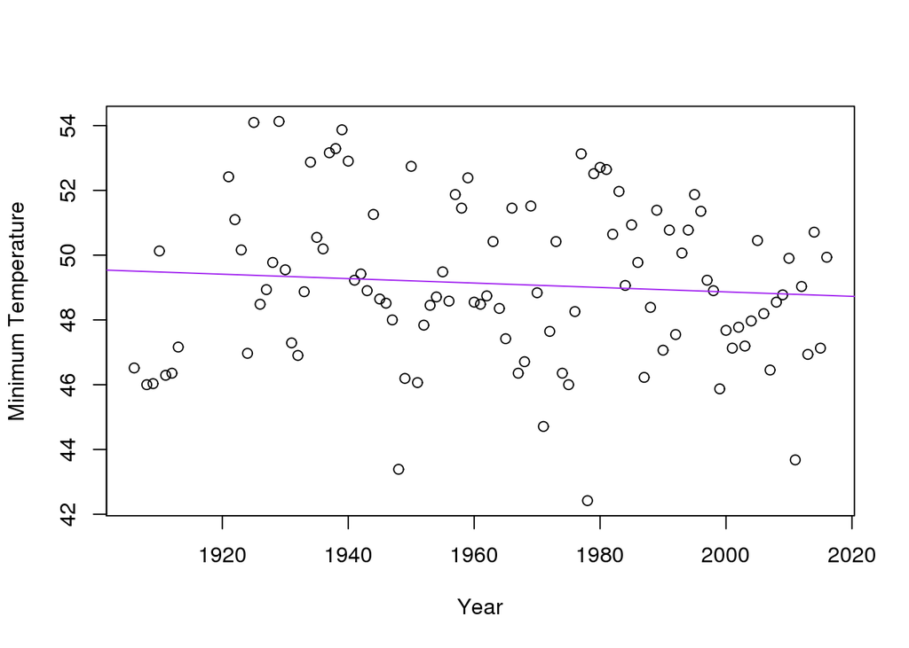

Temperature Change (°F/ year): -0.0068331

(°F/ 100 years): : -0.683

P-value 0.3891.

Unlike the previous 3 results, the average minimum temperature for December appears to be slowly decreasing. However, once again, we see that the p-value for the data is 0.3891 making it insignificant. Sine there is no statistically significant relationship between time and temperature, a decreasing trend, although observed, cannot be confirmed.

Nevertheless, we should explore the observed changes for December as they could potentially have implications for Oklahoma’s climate. Below are the results we have obtained for December:

| Temperature | Change (Degrees Fahrenheit/year) | Change (Degrees Fahrenheit/100 years) | P-value |
| --- | --- | --- | --- |
| Max temperature – December | 0.0159977 | 1.6 | 0.1122 |
| Min temperature – December | -0.0068331 | -0.683 | 0.3891 |

The data shows that maximum temperatures are increasing while minimum temperatures are decreasing. This translates to more extreme climate during the winter season for Oklahoma, as temperatures between day and night will have increasingly larger differences. The statistical insignificances for these data could have resulted from random error or a lack of data, which is why we cannot assume that our observations and trend line are accurate.

Now we repeat this analysis for the minimum and maximum temperatures in June:

| Temperature | Change (Degrees Fahrenheit/year) | Change (Degrees Fahrenheit/100 years) | P-value |
| --- | --- | --- | --- |
| Max temperature – June | 0.0432686 | 4.327 | 3.338e–05 |
| Min temperature – June | 0.0526848 | 5.268 | 8.723e–12 |

Here, a significant statistical relationship between time and minimum/maximum temperatures can be confirmed due to the P-value being less than 0.05. Notice also how the minimum temperature for June is increasing more per decade than the maximum temperature. This indicates how summers will, even at its coolest, be hotter than what we have experienced so far.

# Average Yearly Precipitation

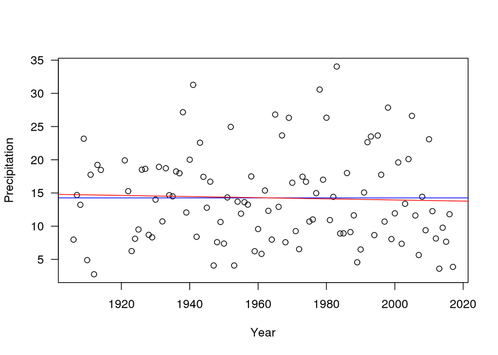

Change in Rainfall (cm/ year): -0.0085364 (cm/ decade): -0.09

Here is a scatter plot of the mean annual precipitation data. The blue straight line represents the mean amount of rainfall in cm (constant). The red line is the trend line of actual overserved rainfall. The trend shows a slight negative relationship between precipitation and time, and also that recorded rainfall is slowly decreasing at a rate of 0.09cm per decade. This trend agrees with the Southern Climate Impact Planning Program’s (SCIPP) prediction that “droughts will become more frequent, last longer, and be more intense” for Oklahoma.

# Discussion (Potential Implications for Oklahoma):

What our results have established are positive relationships between time and temperature in June. It confirmed that although both minimum and maximum temperatures are rising, average minimum temperatures are rising faster than maximum temperatures. The results also showed that yearly precipitation is slowly decreasing for Oklahoma. This means that Oklahoma’s summer climate could, as observed, continue to warm.

As the effects of climate change are predicted to compound, Professor Thomas Karl predicts that by 2040 Oklahoma’s summer temperatures will rise another 2.7–2.9°F (Karl et al.) These predictions are backed up by Environmental Protection Agency (EPA) whose research also forecasts the number of days over 100°F to quadruple by mid-century (Smith et al.) Karl also believes that by the end of the century, annual mean temperatures will increase a total of 9 - 14.6°F.

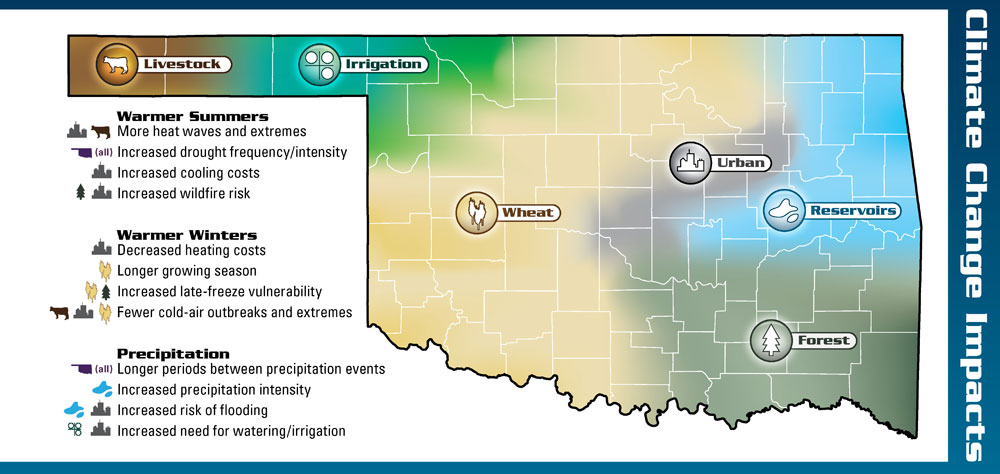

Source: Oklahoma Climatological Survey

Such drastic changes in temperature will have a profound impact on Oklahoma, especially in the livestock, irrigation, wheat, and forest sectors. According to the Oklahoma Climatological Survey, warmer summers will lead to more extremely hot days, heatwaves, droughts, cooling costs and wildfires. These are climate change implications that will affect all of Oklahoma’s citizens if no mitigation efforts are initiated.

In terms of agriculture, shortened winters and longer periods without frost could increase the time it takes to harvest many crops, such as wheat, in Oklahoma. The yield of winter wheat is predicted to experience a 27–37% loss as temperatures exceed the climate threshold. Moreover, as droughts will become more frequent and severe, Oklahoma will need more irrigation to produce the same number of crops.

Climate change will also affect Oklahoma’s wildlife and tourism industry. As temperatures rise, Oklahoma’s wildlife will either adapt or be driven to extinction. Warmer ecosystems will become better environments for invasive species, such as red-imported fire ants. The potential loss of wildlife could impact the tourism industry, which according to the National Wildlife Federation, currently spends more than $1 billion per year on wildlife hunting, viewing, and fishing.

Our precipitation data shows a slight downward trend in average yearly precipitation. However, according to the Southern Climate Impacts Planning Program (SCIPP), Oklahoma has also been experiencing increasingly unpredictable rainfalls, oscillating between extreme droughts and intense downpours. This increase in extreme weather conditions is supported by Professor Karl whose work also predict that by 2040, average rainfall will increase by 3% in the winter and decrease by 2-3% in the summer.

In the past 50 years, the amount of rainfall in the 4 wettest days of the year in Oklahoma has increased by 15%. This number will rise even further as temperatures continue to rise. However, according to the SCIPP, the overall precipitation levels will decrease 6 - 20% by 2100; this elucidates how climate change encourages more extreme weather conditions in Oklahoma. In such a scenario, more floods would occur as “rains following droughts will be quick and heavy, causing flash-flooding and destroying aging and vulnerable infrastructure” (SCIPP).

Water stress is one of the primary climate change concerns for Oklahoma as all its rivers and streams are vulnerable to its effects. The Oklahoma Water Resources Board have documented shifting and shrinking water tables due to prolonged drought, higher temperatures and increased irrigation. Furthermore, the 2014 National Climate Assessment shows that water levels have fallen by over 150ft in some regions of the High Plains Aquifer, which is the main supplier of water in the region. As a result of such observations, the OWRP has designed the Oklahoma Comprehensive Water Plan (OCWP), which proposes strategies and policies that promote water reuse and conservation. This plan could potentially allow Oklahoma to meet its future water demands.

To find our more about the OCWP, visit http://www.owrb.ok.gov/

# Conclusion:

Climate change is potentially a threat-multiplier for Oklahoma, as it encourages more intense and frequent hurricanes, heat waves, floods, droughts, and other extreme weather conditions. Nevertheless, it is difficult to incite change as global warming is caused by a multitude of factors. Making it more difficult is the fact that future predictions are rarely accurate because it is impossible to predict how public attitudes and behaviors towards global warming will change.

The Oklahoma Climatological Survey (OCS) affirmed that “much of the global average temperature increases over the last 50 years can be attributed to human activities. The SCIPP adds that the extent of climate change will, in part, be determined by the level of GHG released into the atmosphere. Thus, if Oklahoma’s citizens were to initiate more action and collaboration to mitigate the effects of climate change, they may potentially lessen its impacts in the future.

# Works Cited

- Sutter, John D. “Woodward County, Oklahoma: Why Do So Many Here Doubt Climate Change?” CNN. N.p., 24 Nov. 2015. Web. 25 Jan. 2017.
- “What We Know.” Earthquakes in Oklahoma. 2016. Web. 25 Jan. 2017. https://earthquakes.ok.gov/what-we-know/.
- Southern Climate Impacts Planning Program. (2004). “Climate Change in Oklahoma.” Oklahoma Dept. of Sustainability and Environment. SCIPP. N.p. Web.
- Karl, Thomas., Melillo, Jerry., Peterson, Thomas. (2009). “3 Projected Climate Change by Geographic Region.” United states Global Research Program (USGCRP). Cambridge University Press, pp 196.
- Smith, Joel., Tirpak, Dennis. “The Potential Effects of Global Climate Change on The United States.” (1989) United States Environmental Protection Agency, Office of Research and Development. pp 177, 287 – 319.
- Crawford, Ken, and Gary McManus. “Statement on Climate Change and Its Implications for Oklahoma.” Oklahoma Climatological Survey. 2007. Web. 25 Jan. 2017. https://www.ok.gov/conservation/documents/climate-statement-ocs.pdf.
- Wertz, Joe. “Drier, Hotter, More Extreme Weather: How Climate Change Is Already Affecting Oklahoma.” NPR. 8 May 2014. Web. 25 Jan. 2017.
- Powell, Emily., Keim, Barry. (2015). “Trends in Daily Temperature and Precipitation Extremes for the Southeastern United States: 1948 – 2012.” Journal of Climate. Vol 28.4. p 1592 – 612.